# Lab 04 - Data visualization

# Learning Goals

- Read in and prepare the meteorological dataset
- Create several graphs with different `geoms()` in `ggplot2`
- Create a facet graph
- Conduct some customizations to the graphs
- Create a more detailed map using `leaflet()`

# Lab Description

We will again work with the meteorological data presented in lecture.

**The objective of the lab is to examine the association between monthly average dew point temperature and relative humidity in four regions of the US and by elevation.**

# Steps

### 1. Read in the data

First download and then read in with data.table:fread()

```r
#download.file("https://raw.githubusercontent.com/USCbiostats/data-science-data/master/02_met/met_all.gz", #"met_all.gz", method="libcurl", timeout = 60)
#Here I have already downloaded the dataset last week.
```

### 2. Prepare the data

- Remove temperatures less than -17C
- Make sure there are no missing data in the key variables coded as 9999, 999, etc
- Take monthly averages by weather station
- Create a region variable for NW, SW, NE, SE based on lon = -98.00 and lat = 39.71 degrees
- Create a categorical variable for elevation as in the lecture slides

```r
met <- data.table::fread("/Users/sherryshen/Desktop/pm566/met_all.gz")
names(met)
```

```
##  [1] "USAFID"            "WBAN"              "year"
##  [4] "month"             "day"               "hour"
##  [7] "min"               "lat"               "lon"
## [10] "elev"              "wind.dir"          "wind.dir.qc"
## [13] "wind.type.code"    "wind.sp"           "wind.sp.qc"
## [16] "ceiling.ht"        "ceiling.ht.qc"     "ceiling.ht.method"
## [19] "sky.cond"          "vis.dist"          "vis.dist.qc"
## [22] "vis.var"           "vis.var.qc"        "temp"
## [25] "temp.qc"           "dew.point"         "dew.point.qc"
## [28] "atm.press"         "atm.press.qc"      "rh"
```

```r
#remove temp <-17
met <- met[met$temp >= -17]
met[met$elev==9999.0] <-NA

#compute monthly averages
met_avg<-met[,.(temp=mean(temp,na.rm=TRUE), rh=mean(rh,na.rm=TRUE), wind.sp=mean(wind.sp,na.rm=TRUE), vis.dist=mean(vis.dist,na.rm=TRUE), dew.point=mean(dew.point, na.rm=TRUE), lat=mean(lat), lon=mean(lon), elev=mean(elev,na.rm=TRUE)), by=c("USAFID")]
dim(met_avg)
```

```
## [1] 1589    9
```

```r
names(met_avg)
```

```
## [1] "USAFID"    "temp"      "rh"        "wind.sp"   "vis.dist"  "dew.point"
## [7] "lat"       "lon"       "elev"
```

```r
met_avg$elev_cat <- ifelse(met_avg$elev> 252, "high", "low")
head(met_avg)
```

```
##    USAFID     temp       rh  wind.sp vis.dist dew.point      lat       lon
## 1: 690150 33.18763 16.71861 3.483560 15903.76  2.238919 34.29982 -116.1658
## 2: 720110 31.22003 53.89934 2.138348 16029.07 19.575662 30.78400  -98.6620
## 3: 720113 23.29317 62.58376 2.470298 15833.99 14.984203 42.54300  -83.1780
## 4: 720120 27.01922 83.53706 2.503079 15685.42 23.877786 32.21747  -80.6998
## 5: 720137 21.88823 76.96870 1.979335 15234.68 17.076999 41.42500  -88.4190
## 6: 720151 27.57686 41.90212 2.998428 16025.76 12.093845 30.38304 -103.6830
##         elev elev_cat
## 1:  692.8508     high
## 2:  336.0000     high
## 3:  222.0000      low
## 4:    6.0000      low
## 5:  178.0000      low
## 6: 1317.4389     high
```

```r
table(met_avg$elev_cat)
```

```
##
## high  low
##  756  832
```

```r
met_avg$region <- ifelse(met_avg$lon > -98 & met_avg$lat >39.71, "north east", ifelse(met_avg$lon > -98 & met_avg$lat <39.71, "south east", ifelse(met_avg$lon < -98 & met_avg$lat >39.71, "north west", "south west")))
table(met_avg$region)
```

```
##
## north east north west south east south west
##        487        147        656        298
```

### 3. Use `geom_boxplot` to examine the dew point temperature and relative humidity by region

- Use facets
- Make sure to deal with `NA` category
- Describe what you observe in the graph

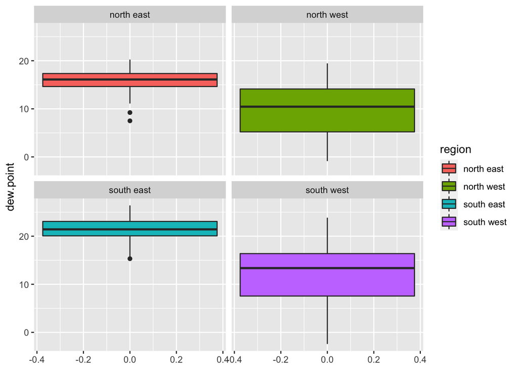

```r
met_avg %>%
  filter(!(region %in% NA)) %>% #remove NA category of region
  ggplot()+
  geom_boxplot(mapping = aes(y=dew.point, fill=region))+
  facet_wrap(~region, nrow=2) #generate individual plot instead one
```

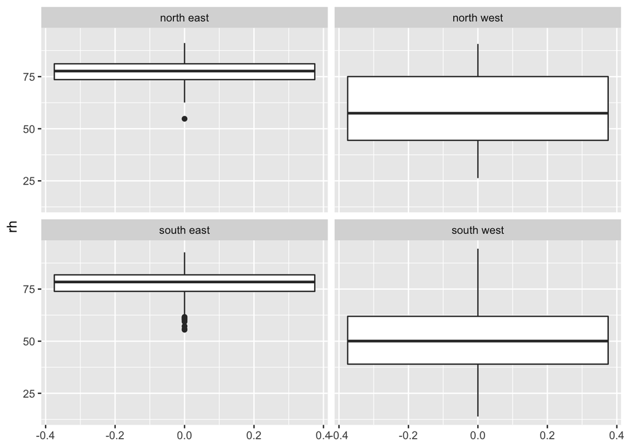

```r
met_avg %>%
  filter(!(region %in% NA)) %>% #remove NA category of region
  ggplot()+
  geom_boxplot(mapping = aes(y=rh))+
  facet_wrap(~region, nrow=2) #generate individual plot instead one
```

We can see that dew.point temperature varies by region. It’s very high in South East because there are more moisture in the air in the Southeastern region. It is drier and colder in the North West. It is drier and a little bit more warmer in the South West.

For the relative humidity, we can see that it is higher in the East and lower in the West.

### 4. Use `geom_point` with `stat_smooth` to examine the association between dew point temperature and relative humidity by region

- Colour points by region
- Make sure to deal with `NA` category
- Fit a linear regression line by region
- Describe what you observe in the graph

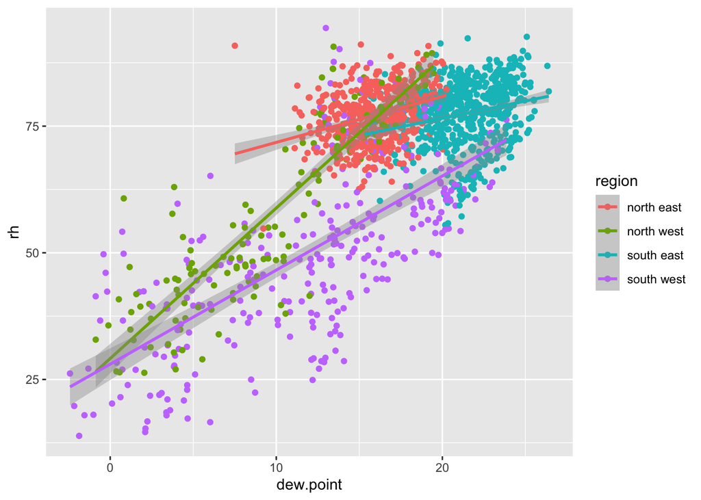

```r
met_avg %>%
  filter(!(region %in% NA)) %>% #remove NA category of region
  ggplot(mapping = aes(x=dew.point, y=rh, color=region))+
  geom_point()+
  stat_smooth(method=lm)
```

From the plot we can see that the association between dew.point and relative humidity is positive in all regions (an increase dew.point is associated with an increase in relative humidity)

In addition, we can also see that wheather is more humid in the North East and South East.

### 5. Use `geom_bar` to create barplots of the weather stations by elevation category coloured by region

- Bars by elevation category
- Change colours from the default. Colour by region using `scale_fill_brewer` see [this](http://rstudio-pubs-static.s3.amazonaws.com/5312_98fc1aba2d5740dd849a5ab797cc2c8d.html)
- Create nice labels on axes and add a title
- Describe what you observe in the graph
- Make sure do teal with ‘NA’

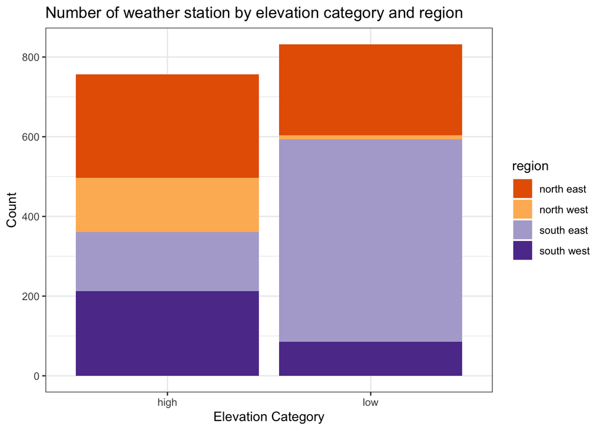

```r
met_avg %>%
  filter(!(region %in% NA)) %>%
  ggplot()+
  geom_bar(mapping = aes(x=elev_cat, fill=region))+
  scale_fill_brewer(palette = "PuOr")+
  labs(titles="Number of weather station by elevation category and region", x="Elevation Category", y="Count")+
  theme_bw()
```

```r
#theme_dark()
```

### 6. Use `stat_summary` to examine mean dew point and relative humidity by region with standard deviation error bars

- Make sure to remove `NA`
- Use fun.data=“mean_sdl” in `stat_summary`
- Describe the graph and what you observe

```r
#install.packages("Hmisc")
library(Hmisc)
```

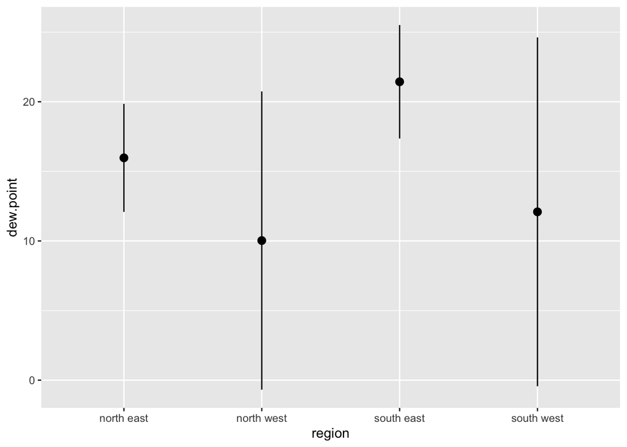

```r
met_avg %>%
  filter(!(region %in% NA)) %>%
  ggplot(mapping = aes(x = region, y = dew.point)) +
  stat_summary(fun.data="mean_sdl")
```

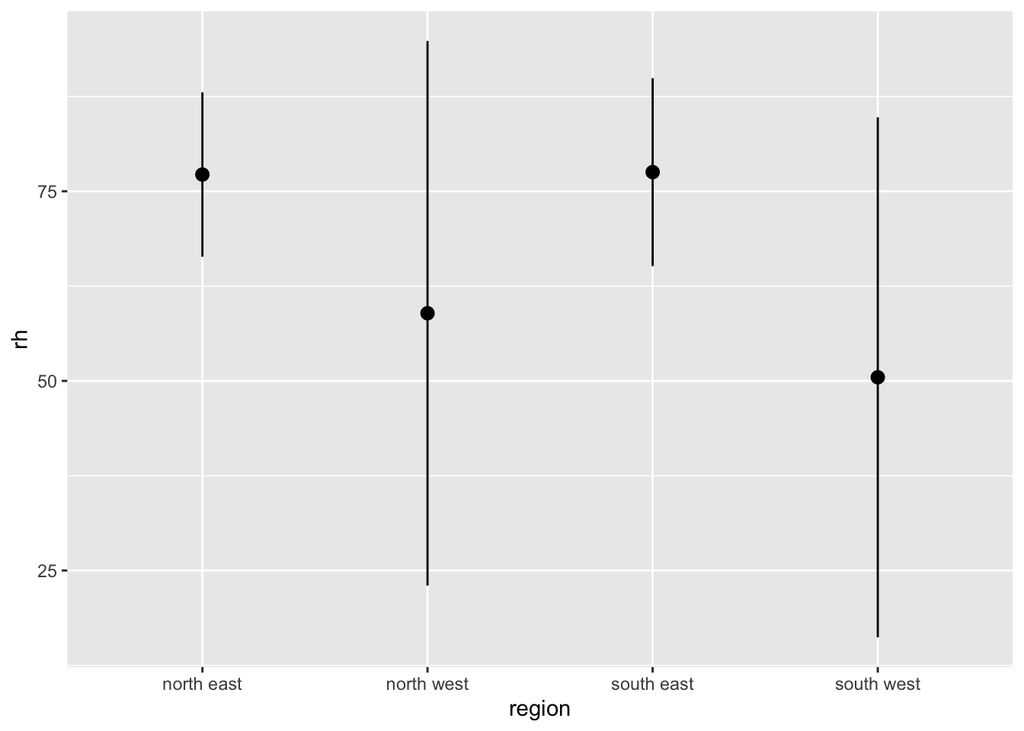

```r
met_avg %>%
  filter(!(region %in% NA)) %>%
  ggplot(mapping = aes(x = region, y = rh)) +
  stat_summary(fun.data="mean_sdl")
```

From the first plot we can see that, South East has the highest dew.point and North West had the lowest dew.point. The standard deviation of dew.point is much smaller in North East and South East. The standard deviation of dew.point is much larger in North West and South West.

For the second plot, South East and North East have high relative humidity. North West and South West have lower relative humidity. The standard deviation of relative humidity is much smaller in North East and South East. The standard deviation of relative humidity is much larger in North West and South West.

### 7. Make a map showing the spatial trend in relative humidity in the US

- Make sure to remove `NA`
- Use leaflet()
- Make a colour palette with custom colours
- Add a legend

```r
met_avg2 <- met_avg[!is.na(rh)]

rh_pal = colorNumeric(c('blue','purple','red'), domain=met_avg2$rh)

leaflet(met_avg2) %>%
  addProviderTiles('OpenStreetMap') %>%
  addCircles(lat=~lat, lng=~lon, color=~rh_pal(rh),opacity=1,
             fillOpacity=1, radius=500) %>%
  addLegend('bottomleft', pal=rh_pal, values=met_avg2$rh,
            title="Relative Humidty", opacity=1)
```

[interactive chart not shown]

From the plot we can see that regions that are near the coast and lakes have high relative humidity. And regions that are in the middle, where there are many the mountains, are pretty dry.  
### 8. Use a ggplot extension

- Pick and extension (except cowplot) from [here](https://exts.ggplot2.tidyverse.org/gallery/) and make a plot of your choice using the met data (or met_avg)
- Might want to try examples that come with the extension first (e.g. ggtech, gganimate, ggforce)

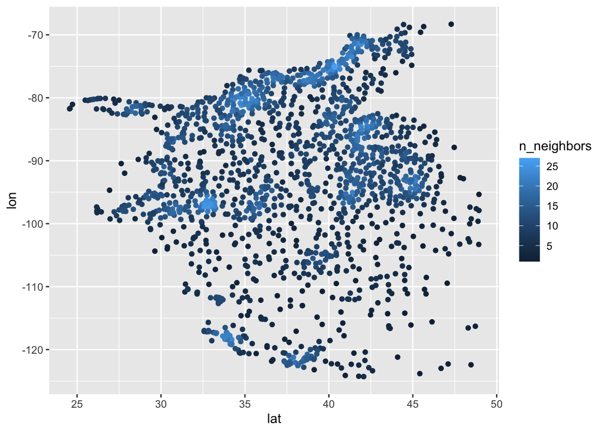

```r
#create new data table having region, day, latitude and longitude.
#install.packages("ggpointdensity")
library(ggpointdensity)

met_avg %>%
  ggplot(mapping = aes(x = lat, y = lon)) +
  geom_pointdensity()
```

By using “geom_pointdensity”, we can see that locations having “light blue” points have larger number of weather stations than locations having “darker blue” points.